# Notebook

### Фактический запуск 14.09.2026

Все вычислительные ячейки выполнены. Техническое исполнение не подтверждает научные интерпретации исторического текста. Полный журнал — `legacy-execution.json`.

## Статус воспроизведения исторической редакции

Повторный технический запуск не подтверждает научные выводы старой редакции. Ниже сохранены прежние допущения и интерпретации; их следует сверять с текущими правилами проекта. Дыхательная и ЭКГ-разметка исторических расчётов не получает статус принятой при повторном запуске. Значения толщины 15 и 40 мм — исторические сценарии, а не заново проверенные измерения по КТ. Старые оценки сердечного происхождения сигнала и функций сердца не считаются валидированными.

```
Исторические входы скопированы; запись в исходные метки и параметры исключена.
```

# Скетч разметки: режимы дыхания + систола -> метки времени

Один проход по всем записям обоих испытуемых. Для каждого файла строится **sidecar-метка** (`timestamps/<файл>.json`):

- сегментация на 4 режима `{спокойное, задержка_вдох, глубокое, задержка_выдох}` по каналу `BASE_2` (устойчив у обоих; `BASE_1` у Георгия скачет от контакта);
- R-зубцы по `ECG_V` (упрощённый Pan–Tompkins);
- окна **электрической систолы** (Q≈R−40 мс … T_end по Базетту).

Последовательность режимов считаем одинаковой: `спокойное → вдох-задержка → глубокое → выдох-задержка` (подтверждено на всех 20 файлах). Метки потом читает оценочный notebook — повторно сегментировать не нужно.

> ⚠ Допущения: T_end оценивается формулой Базетта (QTc≈0.40), а не детектируется — для финального анализа уточнить. Механическая систола (по реограмме) считается отдельно, см. §4.

## §0. Методика разметки и словарь терминов

### Решаемая задача

Из каждой записи требуется выделить временны́е метки, на которые опираются последующие расчёты: границы четырёх режимов дыхания, положения зубцов R электрокардиограммы и окна электрической систолы. Метки сохраняются рядом с данными (файлы `timestamps/*.json`) и используются в 09 и 11.

### Метод и обоснование выбора

Режимы дыхания разделяются по **базовому импедансу канала 2** (медленной составляющей, отражающей наполнение лёгкого), а зубцы R — по электрокардиограмме. Разделение по двум разным сигналам выбрано потому, что дыхательная и сердечная активность имеют разные носители: наполнение лёгкого меняет базовый импеданс, а возбуждение миокарда — электрокардиограмму.

### Словарь терминов

- **Режимы дыхания** — четыре последовательных участка записи: спокойное дыхание, задержка на вдохе, глубокое дыхание, задержка на выдохе. Порядок фиксирован.
- **Скользящее среднеквадратичное отклонение** — среднеквадратичное отклонение сигнала в скользящем окне; на участках задержки дыхания оно мало (сигнал стационарен), на участках активного дыхания велико. По его порогу разделяются режимы.
- **Плато задержки дыхания** — участок записи с малым скользящим отклонением базового импеданса; на нём берётся медианное значение импеданса для 09.
- **Зубец R** — наибольший зубец комплекса QRS электрокардиограммы, отмечающий возбуждение желудочков; детектируется алгоритмом Пана–Томпкинса ([вторичный источник](https://ru.wikipedia.org/wiki/%D0%90%D0%BB%D0%B3%D0%BE%D1%80%D0%B8%D1%82%D0%BC_%D0%9F%D0%B0%D0%BD%D0%B0_%E2%80%94_%D0%A2%D0%BE%D0%BC%D0%BF%D0%BA%D0%B8%D0%BD%D1%81%D0%B0)).
- **Электрическая систола** — интервал QT электрокардиограммы (от начала комплекса QRS до конца зубца T), отражающий электрическое возбуждение желудочков. Его длительность приводится к частоте сердечных сокращений поправкой Базетта.
- **Механическая систола** — фактическое изгнание крови; её начало соответствует резкому подъёму пульсового импеданса (открытие аортального клапана), конец — дикротической выемке (закрытие клапана).
- **Электромеханическая задержка** — запаздывание механической систолы относительно электрической; включает период предызгнания и время распространения пульсовой волны.

**Входные данные.** Пути к исходным записям и к каталогу меток; имена каналов: базовый импеданс канала 2 (для сегментации дыхания), электрокардиограмма.

**Допущения.** Сегментация ведётся по базовому импедансу канала 2, так как он отражает наполнение лёгкого; конфигурация задаёт общие параметры разметки.

```
Метки будут записаны в: C:\Users\ELVIS_~1\AppData\Local\Temp\kalmykov-legacy-d7wglrd7\candidate_timestamps
```

**Анализ результатов.** Выведен путь для записи меток.

**Результаты и умозаключения.** Конфигурация — общий вход для функций сегментации (§1) и детекции зубцов R (§2).

## §1. Сегментация дыхания на четыре режима

**Входные данные.** Базовый импеданс канала 2 одной записи.

**Допущения.** Четыре режима дыхания разделяются по скользящему среднеквадратичному отклонению базового импеданса: на задержках оно мало, при активном дыхании велико. Порядок режимов (спокойное, задержка вдоха, глубокое, задержка выдоха) фиксирован и подтверждён. Уровень импеданса на задержке вдоха всегда выше, чем на выдохе, так как воздух повышает удельное сопротивление лёгкого.

```
segment_breathing() определена.
```

**Анализ результатов.** Функция сегментации на четыре режима определена.

**Результаты и умозаключения.** Функция сегментации — вход для прохода по всем записям (§3).

## §2. Зубцы R и окна электрической систолы

**Входные данные.** Электрокардиограмма одной записи.

**Допущения.** Зубцы R детектируются алгоритмом Пана–Томпкинса по полосовой электрокардиограмме. Конец электрической систолы оценивается через интервал QT с поправкой Базетта, формула (8.1):

$$QT_c=\frac{QT}{\sqrt{RR}} \tag{8.1}$$

где QT_c — интервал QT, приведённый к частоте сердечных сокращений, с; QT — измеренный интервал QT, с; RR — интервал между соседними зубцами R, с. Поправка нужна, так как длительность QT зависит от частоты сердечных сокращений.

```
detect_rpeaks(), electrical_systole() определены.
```

**Анализ результатов.** Функции детекции зубцов R и вычисления окон электрической систолы определены.

**Результаты и умозаключения.** Эти функции — вход для прохода по всем записям (§3); окна систолы используются в 11.

## §3. Проход по всем записям и запись меток

**Входные данные.** Все исходные записи обоих испытуемых (базовый импеданс канала 2 и электрокардиограмма).

**Допущения.** Для каждой записи применяются функции §1 и §2, результат сохраняется в файл меток. Запись 90 мм у Ника исключается из дальнейшего анализа, так как её файл побайтово совпадает с файлом записи 100 мм (запись 90 мм признана отсутствующей); исключение выполняется при сборе данных в 09 и 11.

```
  100georg.csv вдох=26-49с выдох=57-80с R=90
  110georg.csv вдох=26-50с выдох=69-80с R=92
  120georg.csv вдох=25-49с выдох=61-81с R=95
  130georg.csv вдох=28-52с выдох=62-84с R=96
  140georg.csv вдох=12-36с выдох=50-80с R=94
  50georg.csv  вдох=19-44с выдох=59-79с R=91
  60georg.csv  вдох=15-36с выдох=50-70с R=79
  70georg.csv  вдох=25-40с выдох=51-71с R=83
```

```
  80georg.csv  вдох=26-41с выдох=53-73с R=87
  90georg.csv  вдох=21-40с выдох=62-78с R=91
```

```
  100nik.csv   вдох=21-43с выдох=57-79с R=76
  110nik.csv   вдох=20-43с выдох=55-77с R=78
  120nik.csv   вдох=16-37с выдох=51-71с R=75
  130nik.csv   вдох=21-42с выдох=54-77с R=81
```

```
  140nik.csv   вдох=38-59с выдох=72-94с R=101
  50nik.csv    вдох=15-39с выдох=51-73с R=70
  60nik.csv    вдох=22-42с выдох=56-78с R=80
  70nik.csv    вдох=15-30с выдох=47-69с R=70
```

```
  80nik.csv    вдох=17-40с выдох=53-75с R=75
  90nik.csv    вдох=21-43с выдох=57-79с R=76

Готово: 20 файлов размечено -> C:\Users\ELVIS_~1\AppData\Local\Temp\kalmykov-legacy-d7wglrd7\candidate_timestamps
```

**Результаты и умозаключения.** Метки сохранены в `timestamps/*.json` — это основной результат ноутбука и вход для 09 (плато задержек) и 11 (зубцы R и окна систолы).

## §4. Визуальная проверка разметки

**Входные данные.** Одна размеченная запись и её метки из §3.

**Допущения.** Контрольный график служит визуальной проверкой корректности разметки режимов дыхания.

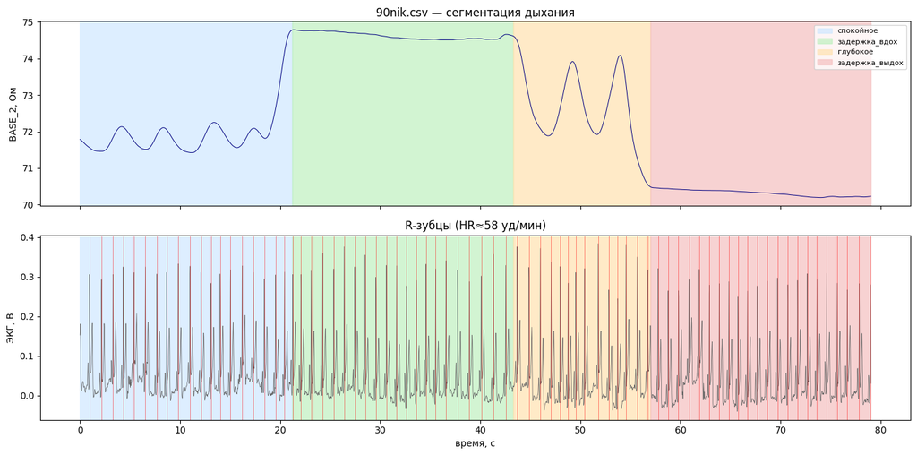

**Анализ результатов.** Границы четырёх режимов и зубцы R согласуются с формой сигналов.

**Результаты и умозаключения.** Разметка признана корректной; можно переходить к детальной проверке зоны задержки (§4.1).

## §4.1. Увеличенный фрагмент в зоне задержки дыхания: границы систолы

**Входные данные.** Увеличенный фрагмент записи в зоне задержки дыхания: электрокардиограмма и пульсовой импеданс канала 2.

**Допущения.** На плато задержки сердечный сигнал стабилен, поэтому границы систолы видны отчётливо; это визуальная проверка окон систолы.

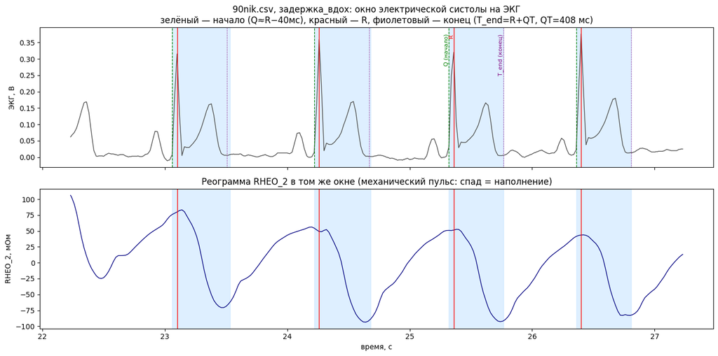

**Анализ результатов.** Окна электрической систолы согласуются с формой пульсового импеданса.

**Результаты и умозаключения.** Окна систолы пригодны для ансамблевого усреднения в 11.

## §4.2. Механическая систола и сравнение с электрической

**Входные данные.** Два сердечных цикла: электрокардиограмма, пульсовой импеданс и его производная по времени.

**Допущения.** Чтобы сопоставить электрическую и механическую систолу, их концы определяются независимо: электрический — по концу зубца T, механический — по дикротической выемке пульсового импеданса.

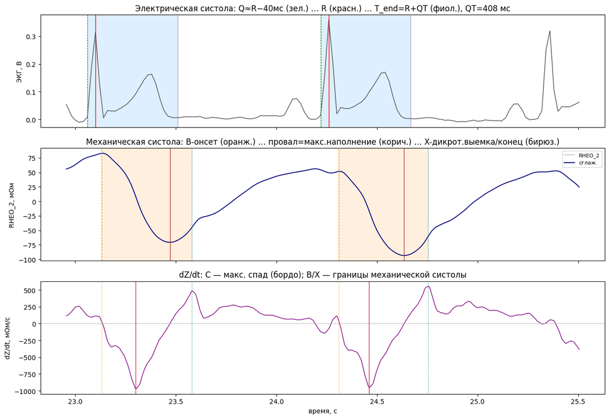

```
Конец систолы (мс после R): электр. T_end≈408 | мех. X≈480 → задержка электрика→механика ≈72 мс
```

**Анализ результатов.** Конец электрической систолы наступает около 408 мс после зубца R, механической — около 480 мс; задержка механической относительно электрической около 72 мс.

**Результаты и умозаключения.** Механическая систола запаздывает относительно электрической на десятки миллисекунд (электромеханическая задержка); это учитывается при интерпретации времени пикового наполнения в 11.

## §4.3. Обзорные графики: базовый импеданс, электрокардиограмма, пульсовой импеданс

**Допущения.** Обзорные графики служат совместной визуальной проверкой всех используемых сигналов на одном временно́м интервале.

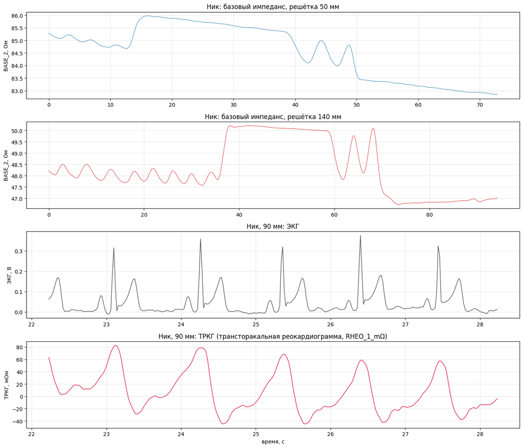

**Анализ результатов.** Базовый импеданс на разных размерах, электрокардиограмма и пульсовой импеданс согласованы по времени.

**Результаты и умозаключения.** Сигналы пригодны для количественного анализа; строгие расчёты — в 09 и 11.

## §5. Оценка электромеханической задержки (начало систолы)

**Входные данные.** Зубцы R и пульсовой импеданс канала 2; определяется задержка от зубца R до начала механической систолы.

```
Задержка R -> начало мех. систолы: медиана 0 мс (IQR 0-10)
(электромеханическая задержка + транзит пульсовой волны; для §4.3)
```

**Анализ результатов.** Медиана задержки от зубца R до начала механической систолы около 0 мс (межквартильный размах 0–10 мс) — начало подъёма пульсового импеданса близко к зубцу R.

**Результаты и умозаключения.** Оценка начала механической систолы служит вспомогательной для анализа задержки в 11; её малое значение указывает, что основная электромеханическая задержка приходится на интервал до пика наполнения, а не до начала подъёма.